# Estudi provisional STACOV - v2

Eudald Correig

27 juny, 2020

# Formateig

Traiem les resines i l’omacor perquè tenen massa poca variabilitat.

Nota: canvio el nom d’Antiagregants.Anticoagulants a A.A perquè si no ocupa massa i les coses es veuen malament.

Mirem quantes dates d’ingrés o alta ens falten:

Hi ha 2 pacients dels quals no tenim la data d’ingrés. Els traiem.

Fem una variable que controla quin esdeveniment de sortida (outcome) té cada pacient:

Hi ha 21 pacients que encara estaven ingressats en el moment d’acabar l’estudi. Els censurem a data de l’últim dia de l’estudi, que és el 5 de juny.

Hi ha encara algun pacient que té 0 dies d’estada:

```
##  [1] "3-093"  "3-099"  "09-101" "09-120" "10-107" "11-044" "13-129"
##  [8] "13-197" "19-022" "20-074"
```

Sumem un dia a tots

Traiem els pacients que tenen pes 0.

La distribució dels temps de seguiment és la següent:

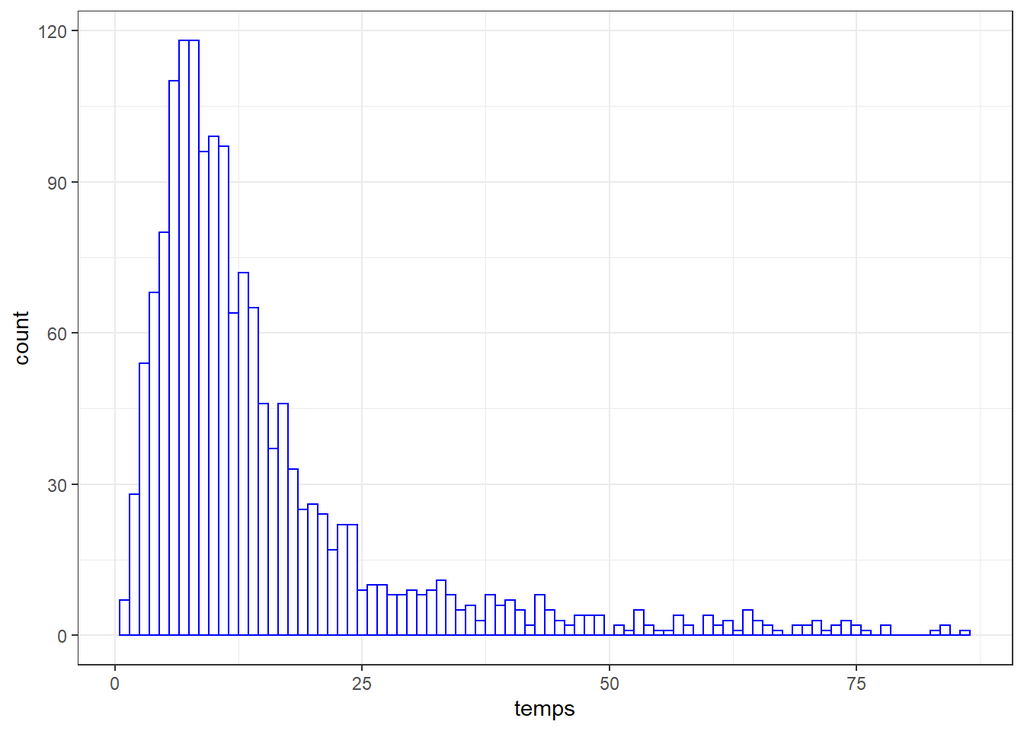

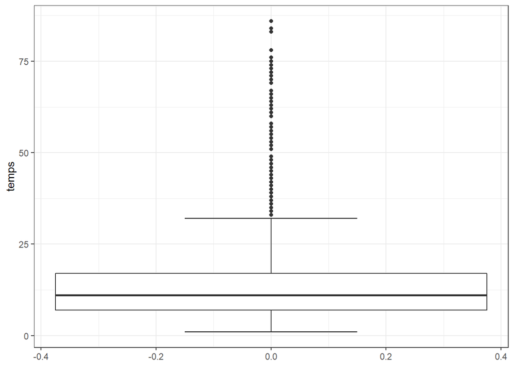

Els descriptius del temps de seguiment són:

```
## df$temps
##        n  missing distinct     Info     Mean      Gmd      .05      .10
##     1597        0       77    0.998    15.04    12.58        3        5
##      .25      .50      .75      .90      .95
##        7       11       17       32       44
##
## lowest :  1  2  3  4  5, highest: 76 78 83 84 86
```

La mediana d’estada són 11 dies, i el rang interquartil va de 7 a 17 dies. El mínim és 1 dia i el màxim 86.

# Descriptiu estatines

Taules descriptives:

## No matxejat

| Variable | Levels | All | No estatins | Statins | Pr(>\|z\|) |
| --- | --- | --- | --- | --- | --- |
| Edat | – | 67 [54 78] | 62 [51 77] | 73 [65 80] | 0 |
| Sexe | Dona | 926 (42.81%) | 701 (44.4%) | 225 (38.53%) | 0.01641 |
| Sexe | Home | 1237 (57.19%) | 878 (55.6%) | 359 (61.47%) | 0.01641 |
| Tabac | No | 1565 (72.35%) | 1206 (76.38%) | 359 (61.47%) | 0 |
| Tabac | Exfumador | 490 (22.65%) | 297 (18.81%) | 193 (33.05%) | 0 |
| Tabac | Sí | 108 (4.99%) | 76 (4.81%) | 32 (5.48%) | 0 |
| HTA | No | 1080 (49.93%) | 941 (59.59%) | 139 (23.8%) | 0 |
| HTA | Sí | 1083 (50.07%) | 638 (40.41%) | 445 (76.2%) | 0 |
| Hiperlipemia | No | 1342 (62.04%) | 1295 (82.01%) | 47 (8.05%) | 0 |
| Hiperlipemia | Sí | 821 (37.96%) | 284 (17.99%) | 537 (91.95%) | 0 |
| Diabetes | No | 1660 (76.75%) | 1335 (84.55%) | 325 (55.65%) | 0 |
| Diabetes | Sí | 503 (23.25%) | 244 (15.45%) | 259 (44.35%) | 0 |
| Obesitat | No | 1588 (73.42%) | 1219 (77.2%) | 369 (63.18%) | 0 |
| Obesitat | Sí | 575 (26.58%) | 360 (22.8%) | 215 (36.82%) | 0 |
| Ant.CI | No | 1958 (90.52%) | 1524 (96.52%) | 434 (74.32%) | 0 |
| Ant.CI | Sí | 205 (9.48%) | 55 (3.48%) | 150 (25.68%) | 0 |
| Ant.Ictus | No | 2028 (93.76%) | 1518 (96.14%) | 510 (87.33%) | 0 |
| Ant.Ictus | Sí | 135 (6.24%) | 61 (3.86%) | 74 (12.67%) | 0 |
| Ant.MVP | No | 2062 (95.33%) | 1544 (97.78%) | 518 (88.7%) | 0 |
| Ant.MVP | Sí | 101 (4.67%) | 35 (2.22%) | 66 (11.3%) | 0 |
| Ant.Ins.Card | No | 1980 (91.54%) | 1481 (93.79%) | 499 (85.45%) | 0 |
| Ant.Ins.Card | Sí | 183 (8.46%) | 98 (6.21%) | 85 (14.55%) | 0 |
| Ant.MPOC.Asma | No | 1796 (83.03%) | 1350 (85.5%) | 446 (76.37%) | 0 |
| Ant.MPOC.Asma | Sí | 367 (16.97%) | 229 (14.5%) | 138 (23.63%) | 0 |
| Ant.MHepC | No | 2105 (97.32%) | 1535 (97.21%) | 570 (97.6%) | 0.72807 |
| Ant.MHepC | Sí | 58 (2.68%) | 44 (2.79%) | 14 (2.4%) | 0.72807 |
| Ant.MRC | No | 1945 (89.92%) | 1467 (92.91%) | 478 (81.85%) | 0 |
| Ant.MRC | Sí | 218 (10.08%) | 112 (7.09%) | 106 (18.15%) | 0 |
| Ant.MReu | No | 2058 (95.15%) | 1511 (95.69%) | 547 (93.66%) | 0.06624 |
| Ant.MReu | Sí | 105 (4.85%) | 68 (4.31%) | 37 (6.34%) | 0.06624 |

[output cut: 97 more lines]

## Matxejat

| Variable | Levels | All | No estatins | Statins | Pr(>\|z\|) |
| --- | --- | --- | --- | --- | --- |
| Edat | – | 75 [65 84] | 76 [65 85] | 73 [65 80] | 0.02976 |
| Sexe | Dona | 728.74 (45.63%) | 503.74 (49.68%) | 225 (38.59%) | 205 |
| Sexe | Home | 868.26 (54.37%) | 510.26 (50.32%) | 358 (61.41%) | 205 |
| Tabac | No | 996.96 (62.43%) | 638.96 (63.01%) | 358 (61.41%) | 0.79943 |
| Tabac | Exfumador | 512.48 (32.09%) | 319.48 (31.51%) | 193 (33.1%) | 0.79943 |
| Tabac | Sí | 87.56 (5.48%) | 55.56 (5.48%) | 32 (5.49%) | 0.79943 |
| HTA | No | 375.14 (23.49%) | 236.14 (23.29%) | 139 (23.84%) | 0.84903 |
| HTA | Sí | 1221.86 (76.51%) | 777.86 (76.71%) | 444 (76.16%) | 0.84903 |
| Hiperlipemia | No | 133.82 (8.38%) | 86.82 (8.56%) | 47 (8.06%) | 0.80001 |
| Hiperlipemia | Sí | 1463.18 (91.62%) | 927.18 (91.44%) | 536 (91.94%) | 0.80001 |
| Diabetes | No | 911.87 (57.1%) | 586.87 (57.88%) | 325 (55.75%) | 0.43792 |
| Diabetes | Sí | 685.13 (42.9%) | 427.13 (42.12%) | 258 (44.25%) | 0.43792 |
| Obesitat | No | 1030.53 (64.53%) | 661.53 (65.24%) | 369 (63.29%) | 0.46635 |
| Obesitat | Sí | 566.47 (35.47%) | 352.47 (34.76%) | 214 (36.71%) | 0.46635 |
| Ant.CI | No | 1193.5 (74.73%) | 760.5 (75%) | 433 (74.27%) | 0.79258 |
| Ant.CI | Sí | 403.5 (25.27%) | 253.5 (25%) | 150 (25.73%) | 0.79258 |
| Ant.Ictus | No | 1418.82 (88.84%) | 909.82 (89.73%) | 509 (87.31%) | 0.1628 |
| Ant.Ictus | Sí | 178.18 (11.16%) | 104.18 (10.27%) | 74 (12.69%) | 0.1628 |
| Ant.MVP | No | 1425.09 (89.24%) | 908.09 (89.55%) | 517 (88.68%) | 0.64576 |
| Ant.MVP | Sí | 171.91 (10.76%) | 105.91 (10.45%) | 66 (11.32%) | 0.64576 |
| Ant.Ins.Card | No | 1355.62 (84.89%) | 857.62 (84.58%) | 498 (85.42%) | 0.70385 |
| Ant.Ins.Card | Sí | 241.38 (15.11%) | 156.38 (15.42%) | 85 (14.58%) | 0.70385 |
| Ant.MPOC | No | 1236.75 (77.44%) | 791.75 (78.08%) | 445 (76.33%) | 0.45645 |
| Ant.MPOC | Sí | 360.25 (22.56%) | 222.25 (21.92%) | 138 (23.67%) | 0.45645 |
| Ant.MHepC | No | 1570.85 (98.36%) | 1001.85 (98.8%) | 569 (97.6%) | 0.10556 |
| Ant.MHepC | Sí | 26.15 (1.64%) | 12.15 (1.2%) | 14 (2.4%) | 0.10556 |
| Ant.MRC | No | 1307.95 (81.9%) | 829.95 (81.85%) | 478 (81.99%) | 0.99788 |
| Ant.MRC | Sí | 289.05 (18.1%) | 184.05 (18.15%) | 105 (18.01%) | 0.99788 |
| Ant.MReu | No | 1439.12 (90.11%) | 893.12 (88.08%) | 546 (93.65%) | 0.00045 |
| Ant.MReu | Sí | 157.88 (9.89%) | 120.88 (11.92%) | 37 (6.35%) | 0.00045 |

[output cut: 89 more lines]

Alerta perquè aquí hi ha valors no enters en alguns casos perquè estem tenin en compte els pesos (és a dir, podem tenir, per exemple, 100.4 persones que fumen i porten estatines)

# Anàlisi univariant

Fem un test de chi^2 per entre prendre estatines o no i morir de covid o no:

```
##
##
##    Cell Contents
## |-------------------------|
## |                       N |
## | Chi-square contribution |
## |           N / Row Total |
## |           N / Col Total |
## |         N / Table Total |
## |-------------------------|
##
##
## Total Observations in Table:  1597
##
##
##              |               No |               Sí |        Row Total |
## -------------|------------------|------------------|------------------|
##           No |              730 |              283 |             1013 |
##              |            1.180 |            3.532 |                  |
##              |            0.720 |            0.280 |            0.635 |
##              |            0.610 |            0.710 |                  |
##              |            0.457 |            0.178 |                  |
## -------------|------------------|------------------|------------------|
##           Sí |              467 |              116 |              583 |
##              |            2.052 |            6.144 |                  |
##              |            0.801 |            0.199 |            0.365 |
##              |            0.390 |            0.290 |                  |
##              |            0.292 |            0.073 |                  |
## -------------|------------------|------------------|------------------|
## Column Total |             1197 |              399 |             1596 |
##              |            0.750 |            0.250 |                  |
## -------------|------------------|------------------|------------------|
##
##
## Statistics for All Table Factors
##
##
## Pearson's Chi-squared test
## ------------------------------------------------------------
## Chi^2 =  12.90744     d.f. =  1     p =  0.0003272778
##
## Pearson's Chi-squared test with Yates' continuity correction
## ------------------------------------------------------------
## Chi^2 =  12.48     d.f. =  1     p =  0.0004113333
##
##
```

Fem un gràfic:

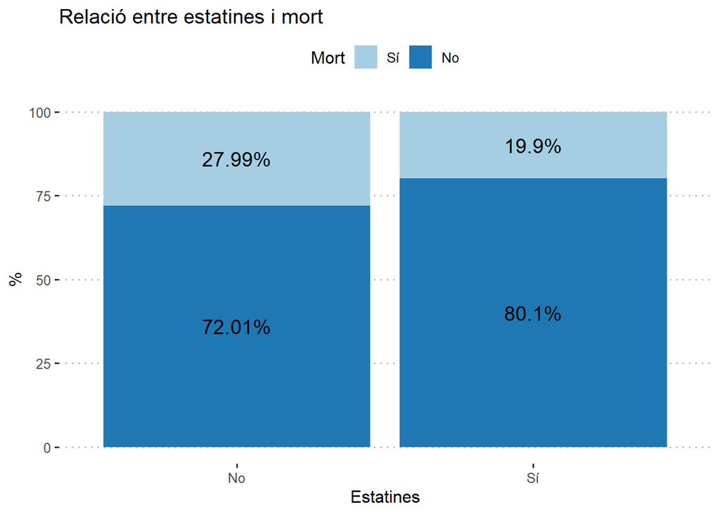

Traiem també els lípids:

# Models de supervivència

Primer dibuixem una Kaplan Meier (per nosaltres, no és per posar a l’article, però a mi m’agraden):

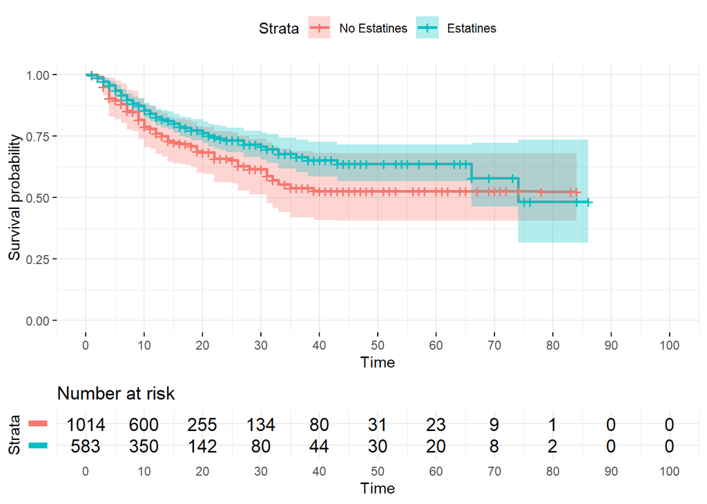

Ara fem un anàlisi de Cause Specific Hazard Ratio

## Cause specific hazard ratio

**Alerta:** posem el punt de tall de l’estudi a 42 dies.

Tenim els següents esdeveniments:

```
##
## censura    alta    mort
##      94    1249     254
```

### Mort

|  | coef | exp(coef) | z | Pr(>\|z\|) |
| --- | --- | --- | --- | --- |
| Edat | 0.070 | 1.073 | 5.787 | 0 |
| TabacExfumador | 0.115 | 1.122 | 0.364 | 0.71594 |
| TabacSí | 1.148 | 3.150 | 2.460 | 0.01388 |
| HTASí | 0.415 | 1.515 | 1.435 | 0.15141 |
| HiperlipemiaSí | 0.343 | 1.409 | 1.321 | 0.18663 |
| DiabetesSí | 0.007 | 1.007 | 0.019 | 0.98474 |
| ObesitatSí | 0.001 | 1.001 | 0.005 | 0.99604 |
| Ant.CISí | -0.921 | 0.398 | -3.251 | 0.00115 |
| Ant.IctusSí | 0.305 | 1.357 | 1.193 | 0.23304 |
| Ant.MVPSí | 0.601 | 1.825 | 2.275 | 0.0229 |
| Ant.Ins.CardSí | 0.044 | 1.045 | 0.160 | 0.87316 |
| Ant.MPOCSí | 0.056 | 1.058 | 0.254 | 0.79946 |
| Ant.MHepCSí | -1.216 | 0.296 | -1.374 | 0.16935 |
| Ant.MRCSí | 0.477 | 1.612 | 1.949 | 0.0513 |
| Ant.MReuSí | -0.261 | 0.770 | -0.588 | 0.5565 |
| CàncerSí | 0.914 | 2.494 | 3.577 | 0.00035 |
| EstatinesSí | -0.388 | 0.679 | -2.021 | 0.04328 |
| EzetimibaSí | 1.326 | 3.767 | 2.328 | 0.01992 |
| FibratSí | 0.564 | 1.757 | 1.328 | 0.1842 |
| IECASí | -0.341 | 0.711 | -1.315 | 0.18843 |
| ARA2Sí | -0.685 | 0.504 | -2.271 | 0.02314 |
| InsulinaSí | 0.041 | 1.042 | 0.121 | 0.90403 |
| ISGLT2Sí | 0.613 | 1.846 | 0.879 | 0.37916 |
| GLP1Sí | -0.109 | 0.897 | -0.194 | 0.84645 |
| Trac.DMSí | 0.415 | 1.514 | 1.213 | 0.22499 |
| A.A.NACOs | -0.326 | 0.722 | -0.771 | 0.44043 |
| A.A.No | -0.336 | 0.714 | -1.323 | 0.18594 |
| A.A.Sintrom | 0.075 | 1.078 | 0.235 | 0.81452 |

Dibuixem les corbes de supervivència:

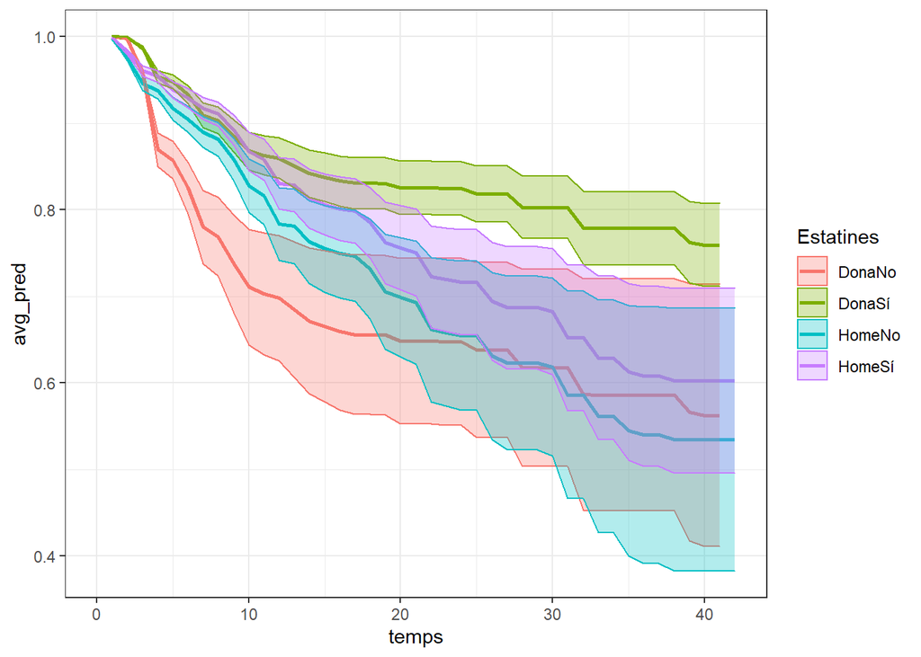

Separem entre homes i dones perquè es vegi millor (i, ja que hem estratificat els models, té més sentit):

### Dones

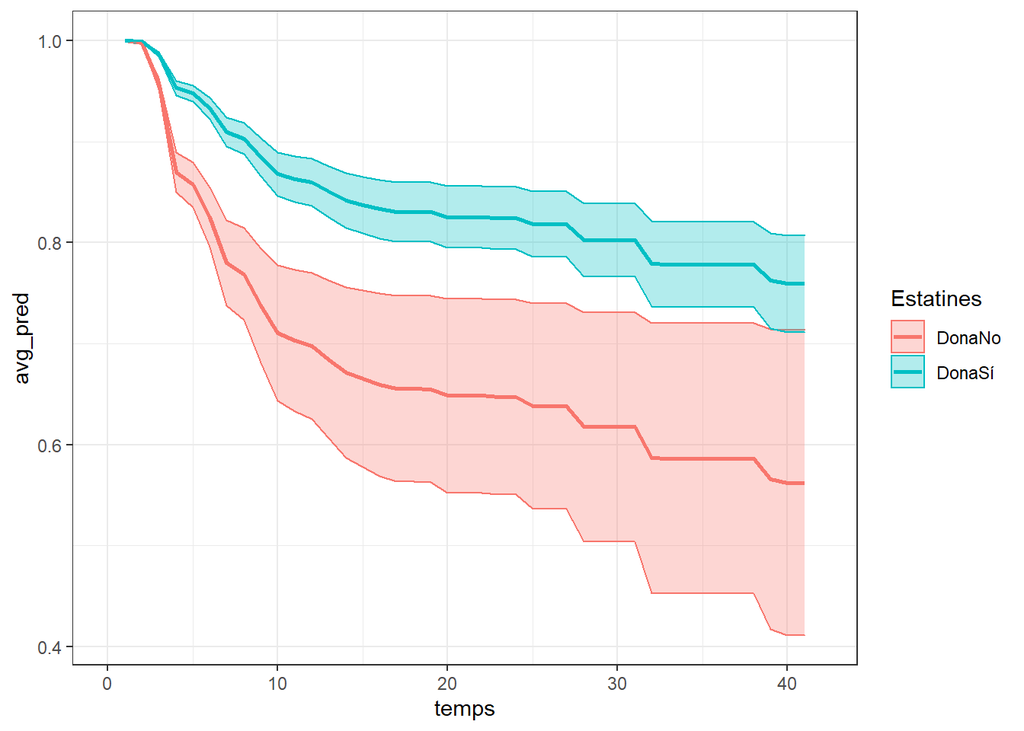

### Homes

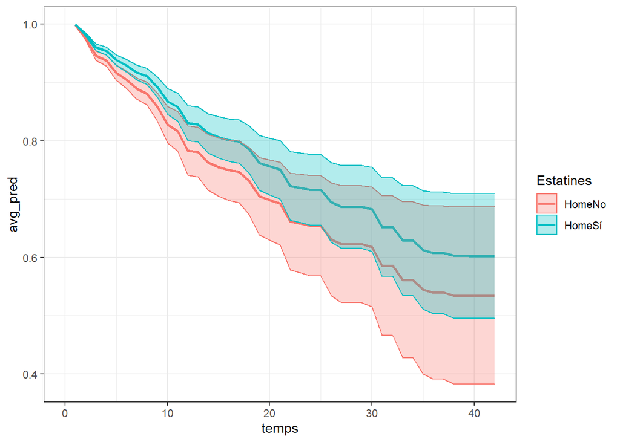

Forest plot:

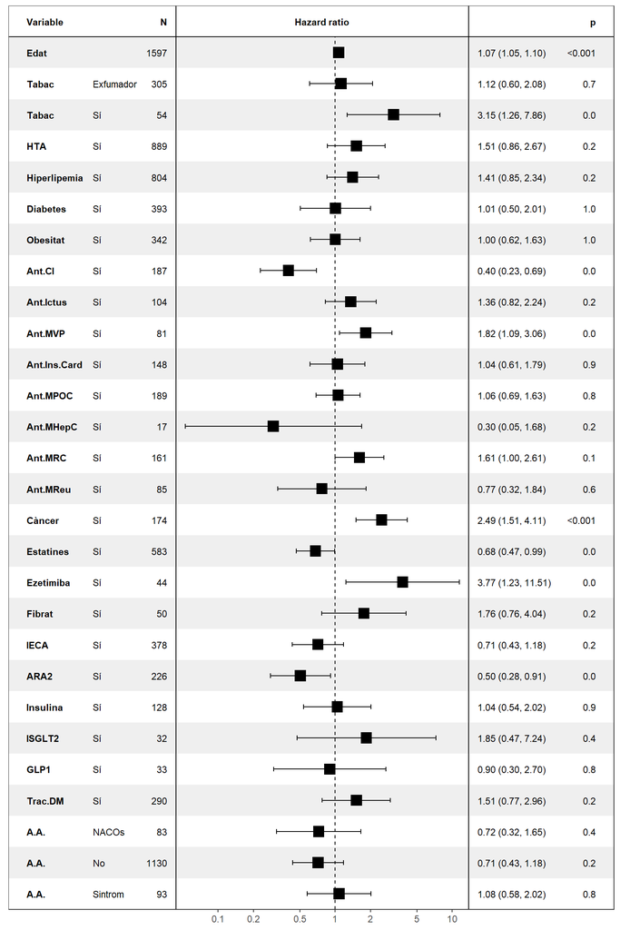

### Alta

|  | coef | exp(coef) | z | Pr(>\|z\|) |
| --- | --- | --- | --- | --- |
| Edat | -0.011 | 0.989 | -2.185 | 0.0289 |
| TabacExfumador | 0.027 | 1.027 | 0.187 | 0.85155 |
| TabacSí | -0.133 | 0.875 | -0.632 | 0.52724 |
| HTASí | -0.200 | 0.819 | -1.594 | 0.11085 |
| HiperlipemiaSí | 0.038 | 1.038 | 0.237 | 0.81283 |
| DiabetesSí | 0.141 | 1.152 | 0.770 | 0.44111 |
| ObesitatSí | -0.134 | 0.874 | -1.078 | 0.28089 |
| Ant.CISí | 0.307 | 1.359 | 2.038 | 0.04154 |
| Ant.IctusSí | 0.238 | 1.269 | 1.556 | 0.11975 |
| Ant.MVPSí | -0.342 | 0.711 | -1.971 | 0.04877 |
| Ant.Ins.CardSí | 0.182 | 1.199 | 0.979 | 0.32761 |
| Ant.MPOCSí | 0.115 | 1.122 | 0.785 | 0.43272 |
| Ant.MHepCSí | -0.045 | 0.956 | -0.143 | 0.88657 |
| Ant.MRCSí | 0.003 | 1.003 | 0.017 | 0.98669 |
| Ant.MReuSí | -0.540 | 0.582 | -2.062 | 0.03921 |
| CàncerSí | 0.227 | 1.255 | 1.181 | 0.23767 |
| EstatinesSí | 0.038 | 1.039 | 0.333 | 0.7389 |
| EzetimibaSí | 0.007 | 1.007 | 0.027 | 0.97844 |
| FibratSí | -0.135 | 0.874 | -0.582 | 0.56034 |
| IECASí | 0.120 | 1.128 | 0.861 | 0.38937 |
| ARA2Sí | 0.270 | 1.310 | 1.788 | 0.07381 |
| InsulinaSí | -0.251 | 0.778 | -1.495 | 0.13481 |
| ISGLT2Sí | 0.117 | 1.124 | 0.375 | 0.7075 |
| GLP1Sí | 0.427 | 1.532 | 2.383 | 0.01718 |
| Trac.DMSí | -0.483 | 0.617 | -2.744 | 0.00606 |
| A.A.NACOs | -0.108 | 0.897 | -0.569 | 0.56959 |
| A.A.No | -0.146 | 0.865 | -0.952 | 0.34087 |
| A.A.Sintrom | -0.253 | 0.777 | -0.936 | 0.34935 |
| ids | 0.000 | 1.000 | 1.898 | 0.05769 |

Dibuixem les corbes de supervivència:

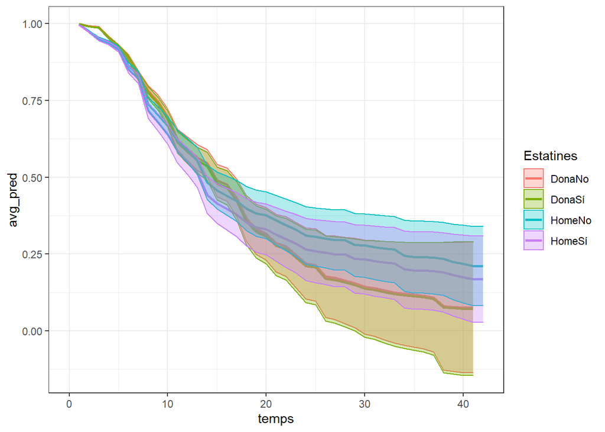

Separem entre homes i dones perquè es vegi millor (i, ja que hem estratificat els models, té més sentit):

### Dones

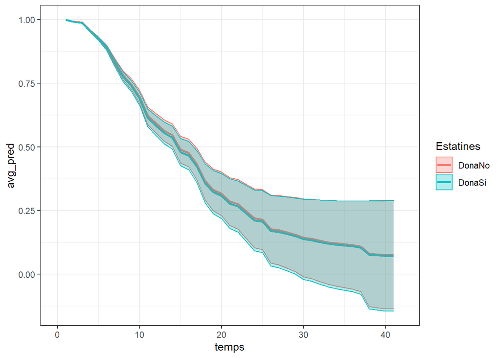

### Homes

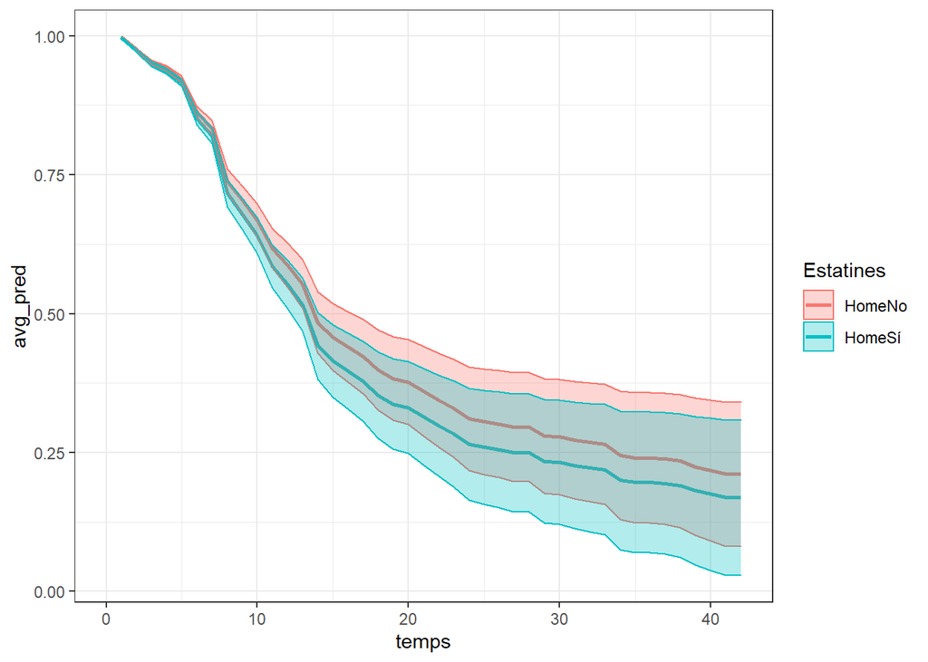

Forest plot:

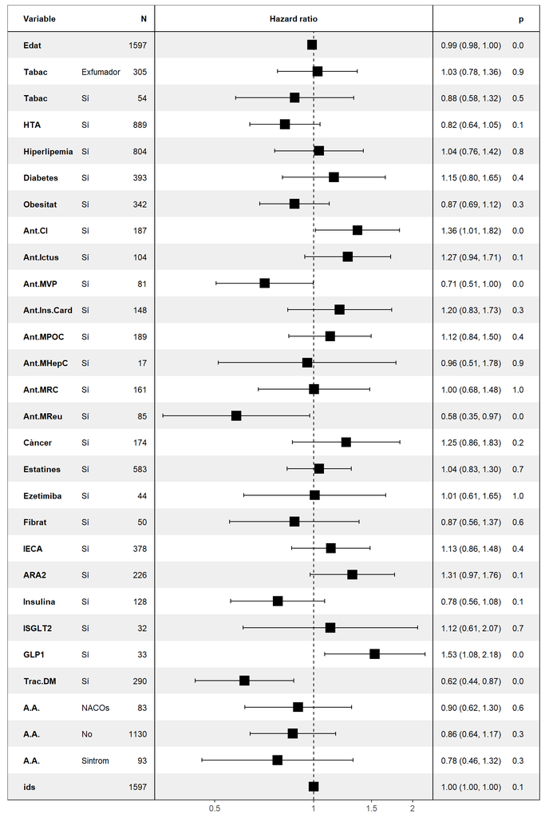

I acabem per un competing risk

## Competing risk

### Mort

[output not shown]

Corbes d’acumulació d’esdeveniments:

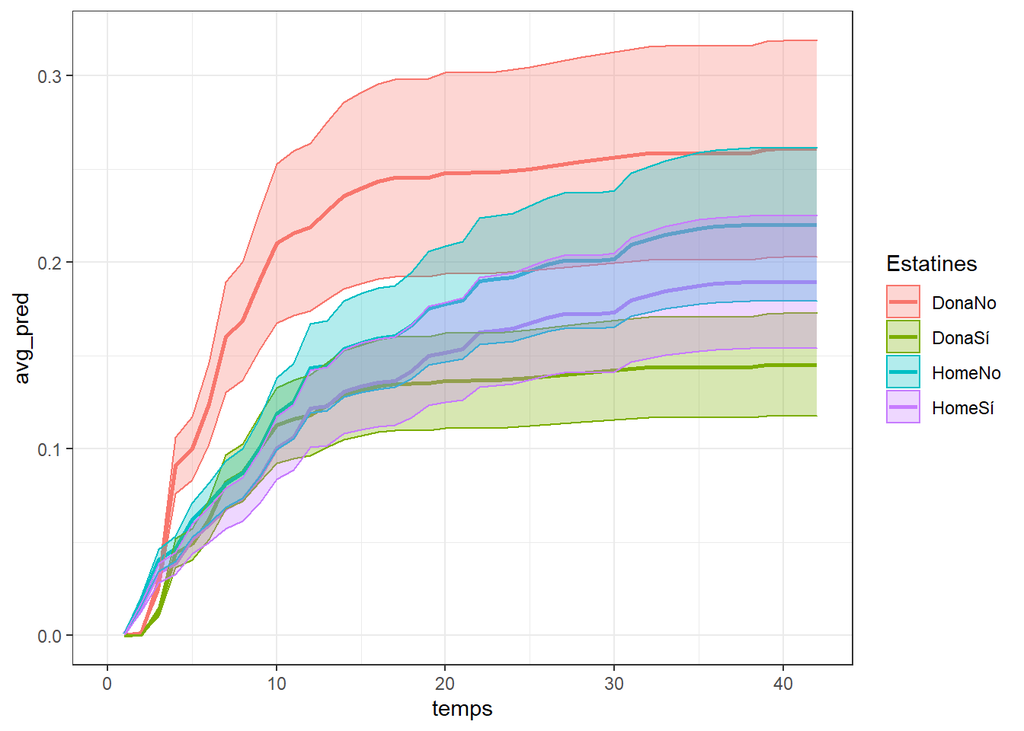

Tornem a separar entre homes i dones:

### Dones

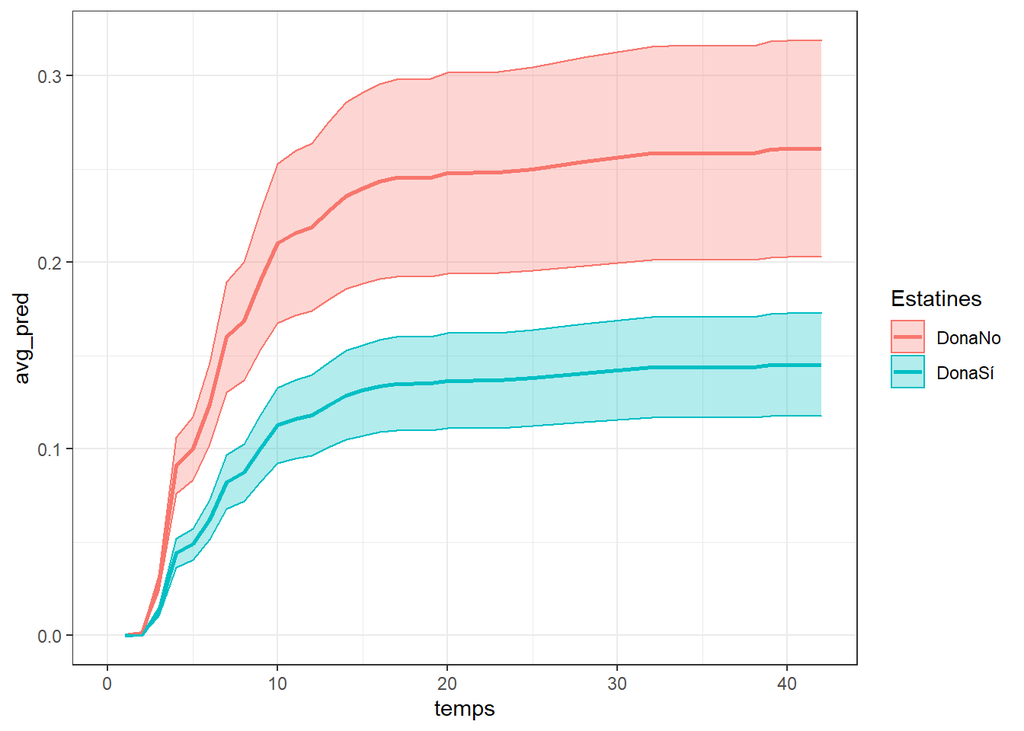

### Homes

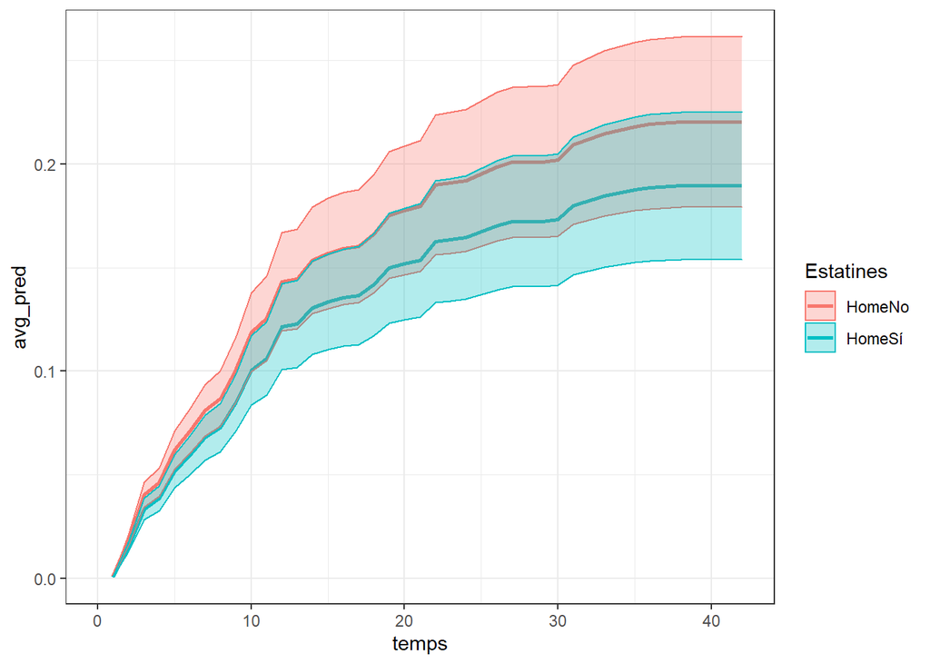

### Alta

[output not shown]

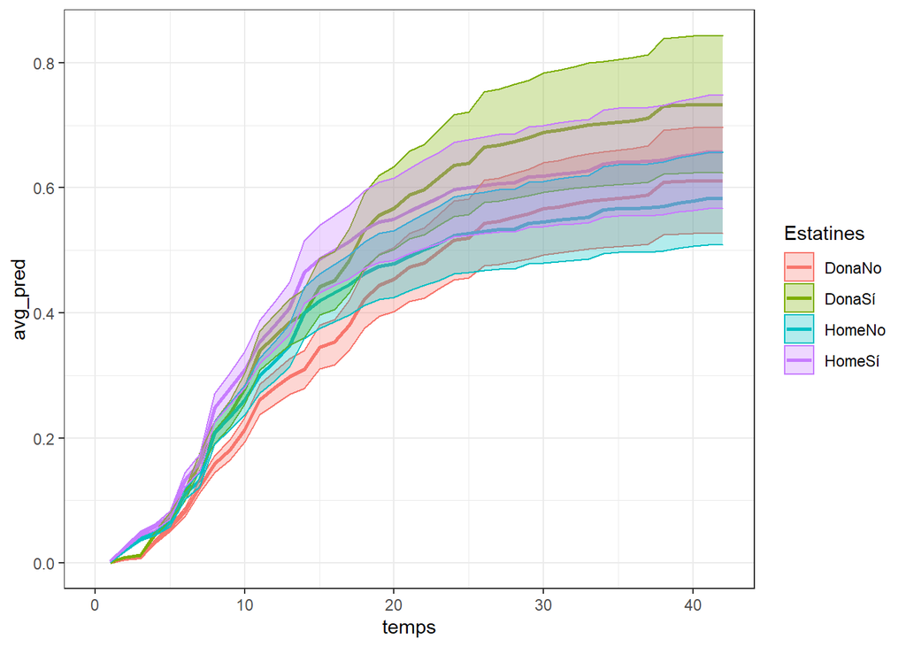

Tornem a separar entre homes i dones:

### Dones

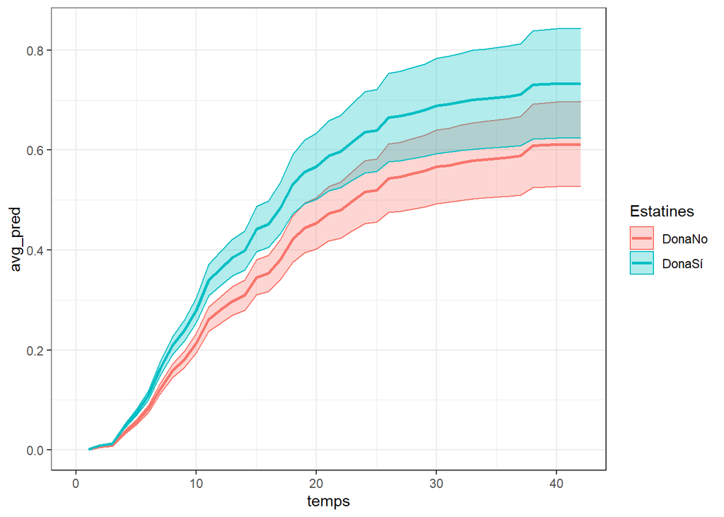

### Homes

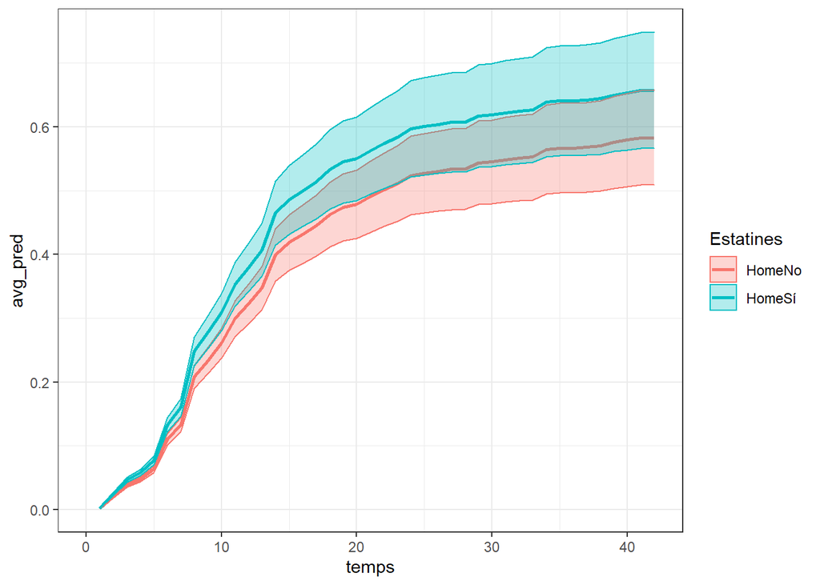